# Nonstationary and Persistent Time Series

73-374 Econometrics II

## Today

- Estimation and inference with persistent time series
  - Reasons for persistence
  - Problems caused by persistence
  - Testing
- Results crucial when handling financial data
  - Easy ways to lose money in the stock market!
- Chapter 12, 18 in Wooldridge

## Time series dependence: Review

- Recall, a time series $Y_t$ is stationary and weakly dependent if $E[Y_t]=E[Y_s]$, $Cov(Y_t,Y_{t+h})=Cov(Y_s,Y_{s+h})$ $\forall\ s\neq t$ and $Cov(Y_t,Y_{t+h})\rightarrow 0$ quickly enough
- Law of large numbers (“Ergodic Theorem”) and (modified) Central Limit Theorem hold
- Allows the series to be used in a regression with more or less usual results, up to a modified standard error formula
- Historical events can be treated like “samples” of underlying process
- Need future to be comparable to past, and not too related to it
- This can be reasonable *if* we directly account for characteristics that do change over time

## Dealing with nonstationary data

- Most basic approach
  - Transform series so that transformed series is stationary
- In any model built out of stationary components, can solve for the stationary variable
- For trend stationary data, can “detrend”
  - Regress series on function of time and use residual
  - Or include function of time in regression
- Transformed variables are stationary but regression equation may have different interpretation
  - GDP not stationary but GDP growth might be

## Integrated Series

- Series where source of nonstationarity is random much harder to deal with
- Random walk $Y_t=Y_{t-1}+e_t$ typical example of series with **stochastic trend**
- Series drifts far away from any particular value, but this drift is not on preset path
- With constant, $Y_t=b_0+Y_{t-1}+e_t$, expected to increase by $b_0$ each period, but doesn’t stay close to line
- A series $Y_t$ is called **integrated** (of order 1) if
  - $Y_t$ nonstationary, $\Delta Y_t$ stationary,
- Asset prices, exchange rates, many macro variables seem to look like this
- A possible solution
  - Remove both trends by *differencing*: $\Delta Y_t= b_0 + e_t$ stationary

## What if source of nonstationarity not known?

- How can we detect it?
  - Measure dependence
  - Apply hypothesis tests
- What if we don’t account for it?
- What are our options to deal with it?

## Daily log price, S&P 500 (1-04-2010-Last Week): (Code)

```r
#Install data library (uncomment if needed)
#install.packages("quantmod",
#  repos="http://cran.us.r-project.org")
library(quantmod) #Use quantmod to download data
#Get S&P500 Data
getSymbols("^gspc",src="yahoo",from = "2010-01-01")
spdata<-as.ts(GSPC) # Turn into time series format
sp500<-spdata[,6] #Extract just adjusted closing price
lsp500<-log(sp500) #Take logs
library(dynlm)
dftest<-dynlm(d(lsp500)~L(lsp500)+trend(lsp500))
#Plot log prices
ts.plot(lsp500)
```

## Daily log price, S&P 500 (1-04-2010-Last Week): Looks persistent

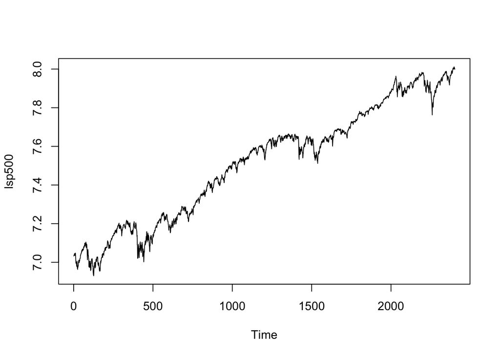

## Differenced daily log price, S&P 500 (Code)

```r
#Plot Differenced series
ts.plot(diff(lsp500))
```

## Differenced daily log price, S&P 500: looks less persistent

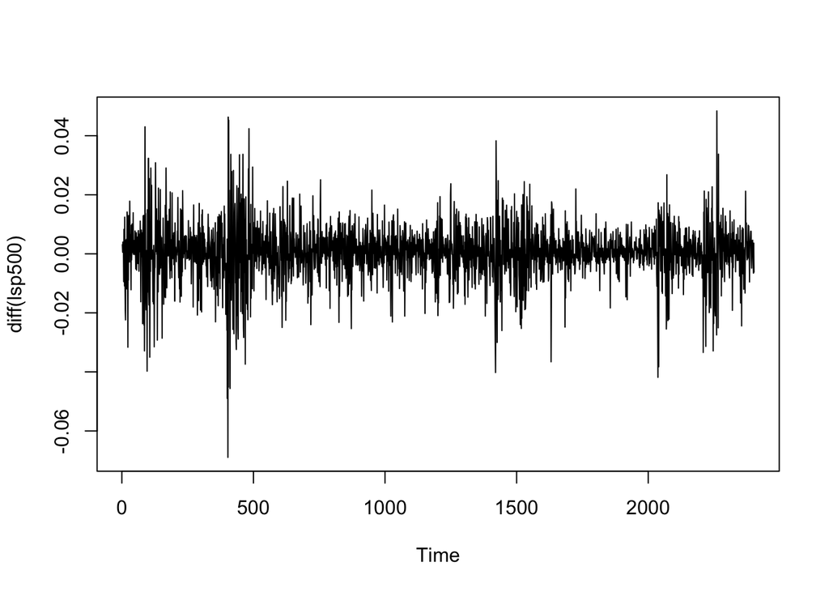

## A tool for detecting dependence: the Autocorrelation Function (ACF)

- ACF measures dependence between time periods
- Autocovariance is $V(h)=Cov(Y_t,Y_{t+h})$
- Should go to 0 and rapidly if series is weakly dependent
- Traditional to divide by variance to get correlation instead of covariance
  - $\gamma (h)=Corr(Y_t,Y_{t+h})=\frac{V(h)}{V(0)}$
- Estimate by sample correlations, display chart
- If it goes towards 0 quickly consistent with weak dependence
- If not, may need to adjust series before using in regression
- Shape may also be informative about structure
  - e.g. AR(1) $Y_t=\rho Y_{t-1} + e_t$ has ACF $\gamma (h)= \rho^h$
  - For random walk, acf declines linearly
  - For MA(q), drops to 0 after q periods
- $acf()$ in $R$

## Autocorrelation function of daily log price, S&P 500

```r
#Plot Autocorrelation function of log S&P 500
acf(lsp500,lag.max=120)
```

## Autocorrelation function of daily log price, S&P 500

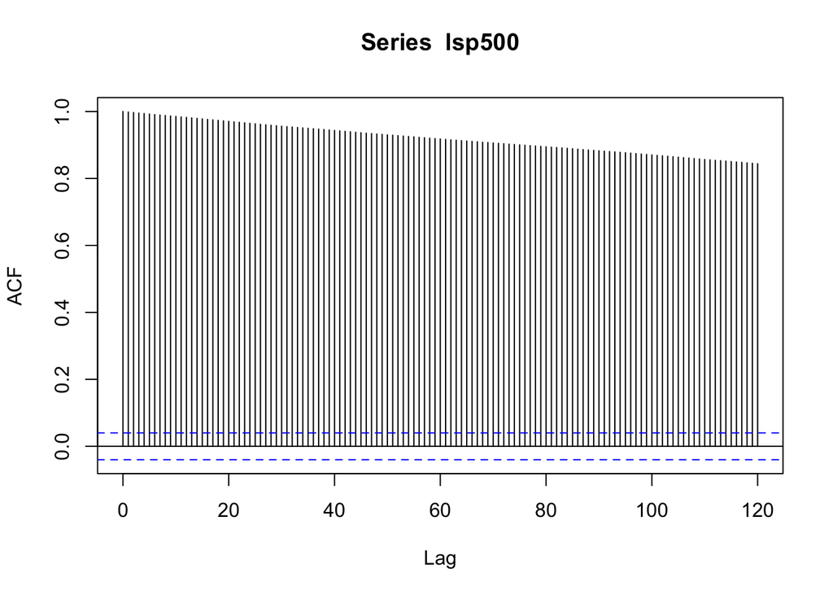

## Unit roots

- Random walk model one example of strongly dependent series
  $$Y_t=\rho Y_{t-1}+e_t$$
- Where $\rho=1$, $E[e_t|Y_{t-1}]=0$
- Generalizes to **unit root** process: $e_t$ any stationary process
- Maybe have trend or constant also: $Y_t=b_0 + b_1 t + Y_{t-1}+e_t$
- $Y_t=e_t+e_{t-1}+e_{t-2}+e_{t-3}+\ldots+Y_0$
- Acts like a sum, instead of a single variable
  - $\frac{1}{t}(Y_t-Y_0)\overset{p}{\rightarrow}E[e_t]$, $\frac{1}{\sqrt{t}}(Y_t-Y_0)\overset{d}{\rightarrow}N(0,\Sigma_{e})$
  - This messes up a lot of our usual regression results
  - May get spurious correlations even when no deterministic trend
- If we know we have a unit root, can take difference
- But how do we know?

## Sources of unit roots

- Lots of series look like unit roots, especially asset prices
- Not a coincidence: consider following argument
- Suppose $E[price_{t+1}|\text{info today}]>price_t$
  - Buy as much as you can today, sell tomorrow, make a ton of money
- Suppose $E[price_{t+1}|\text{info today}]<price_t$
  - Sell a ton today, buy tomorrow, make a ton of money
- So if $E[price_{t+1}|\text{info today}]\neq price_t$ possible to make a lot of money very fast
- This is an **Arbitrage** argument
- Price should be close to a unit root
- Need to borrow money to do this, at interest rate $r$, so should actually be $E[price_{t+1}|\text{info today}]= price_t+r$, unit root with drift
- Also only make a lot of money *on average*
  - Argument may not be exact: correct for risk, etc

## Problems with nonstationarity

- When $Y_t$, $X_t$ nonstationary, law of large numbers and CLT fail
  - Can’t trust tests or confidence intervals
- If both series integrated, both have mean changing over time
- Acts like “time” is omitted variable, even though no deterministic trend
- Regressions will yield large and statistically significant coefficients
  - Relationship just as likely to go in opposite direction in the future
  - Spurious/nonsense regression
- Deterministic detrending won’t solve this
  - “Trend” is random, not of any fixed functional form
- Huge problem when working with financial data
  - Easy to regress stock price on another variable and get big coefficient
  - Relationship will disappear in the future
  - If you trade on this, you will lose money

## What to do about it?

- If you work with economic data, means you should be careful when working with time series, since data may look like unit root and then usual methods have issues
- Applies to more than just financial data because many things can be function of prices
- Can resolve by taking differences if needed
- If you work in finance, care much more about exactly unit root or only approximately
- Arbitrage argument only says that price should behave this way, or else someone can make a lot of money
- Many behavioral reasons to think this is only approximate
- If not exact, can trade and make money from deviations
  - Somebody has to, for result to hold
- Many hedge funds do (more sophisticated version of) this
- Either way, useful to have explicit hypothesis test for unit root

## Unit root testing

- Model is $Y_t=\rho Y_{t-1}+e_t$
- $H_0:\ \rho=1$, $H_1:\ \rho<1$
- Setup looks like a regression problem: regress $Y_t$ on $Y_{t-1}$
- Under $H_0$, $Y_t$ not stationary, so usual regression results fail
- Rewrite as $\Delta Y_t=\theta Y_{t-1} +e_t$
- $H_0:\ \theta=0$, $H_1:\ \theta<0$
- Still have nonstationary regressor
  - But run OLS anyway
  - Use standard t statistic
- Turns out this works, under some conditions
  - But can’t use usual normal/Student t critical values

## Dickey-Fuller Test

- Let $\Delta Y_t=\theta Y_{t-1} +e_t$
- Assume $e_t$ is mean 0 serially uncorrelated homoskedastic series: pure random walk
- Regress $\Delta Y_t$ on $Y_{t-1}$ to get $\hat{\theta}$, construct usual standard error formula $\widehat{S.E.}_{\hat{\theta}}$
- Test statistic is usual t statistic $t_{DF}=\frac{\hat{\theta}}{\widehat{S.E.}_{\hat{\theta}}}$
- Under $H_0$, $t_{DF}$ has, not a normal or Student t distribution, but a **Dickey-Fuller** distribution
- Tables of one sided critical values in your book
  - Or in standard software
- In practice, pure random walk assumption too strong
- Can add a constant to regression to allow for drift
  - Can also add time trend
  - Distribution under $H_0$ changes, but tables/software still exist

## Accounting for serial correlation in root testing

- 0 Serial correlation in $e_t$ is strong assumption
- Can relax it by also adding lags of $\Delta Y_t$ to regression
  - $\Delta Y_t =\theta Y_{t-1}+ \beta_1\Delta Y_{t-1}+\ldots\beta_{k}\Delta Y_{t-k}+e_t$
- Include enough lags until residual is serially uncorrelated
  - Add constant and time trend also if needed
- This version is called **Augmented Dickey Fuller** test
- **ur.df** in **urca** library in R, also versions in **tseries** or **forecast**
- Adding lags may not be enough to make residual serially uncorrelated and homoskedastic
- Resolve by using Newey West (Heteroskedasticity and Autocorrelation-Consistent) standard errors
  - This version is called **Phillips Perron** test (also in R)
- All have nonstandard critical values
  - Don’t rely on usual p values!

## Testing for Unit Root in S&P 500 (log) price (Code)

```r
library(urca)
#ADF tests
spADF0<-ur.df(lsp500,type="drift",lags=0)
t0<-spADF0@teststat[1] #t value, no lags
spADF1<-ur.df(lsp500,type="drift",lags=1)
t1<-spADF1@teststat[1] #t value, 1 lag
#Phillips Perron test
spPP<-ur.pp(lsp500,type="Z-tau",model="constant")
ppt<-spPP@teststat #t value, robust errors
```

## Application: Testing for Unit Root in S&P 500 (log) price

- Economic argument says price should be unit root with drift
- Also suggests there should be no serial correlation in residuals
- But can include anyway to be safe
- Run ADF test with constant but no trend, and with 0 or 1 lags
- Results the same: t-stat is -0.7427572 or -0.6984625
- 10% and 5% Critical values are -2.57 and -2.86 for both
  - Can’t reject at 5% level
- Theory says nothing about heteroskedasticity (and well known that stock prices appear to have non-constant volatility) so may want robust test
- Phillips Perron test gives statistic -0.6650779
- 10%, 5%, 1% critical values -2.5676997, -2.8632418, -3.4360036
- Evidence against unit root hypothesis not strong
- In practice, finance researchers almost always work with difference in price (called “return”), not price itself

## What to do with series with a unit root

- So you test your series and find you can’t reject unit root
- If you care about $\rho$ in $Y_t=\rho Y_{t-1}+e_t$, $\rho=1$ not rejected just means it can’t be ruled out, not that $1$ is best estimate
- Simplest solution is to difference if unsure
  - Removes stochastic and linear trends
- If $Z_t$ is in fact stationary, $\Delta Z_t$ stationary too, so not much harm if used in regression
- After differencing can use in regression
  - Interpret relationships in terms of *changes*
  - May get less precise estimates when true relationship exists
- Other detrending methods may have different properties

## Persistent Data: Conclusions

- Many economic time series exhibit nonstationary behavior
- If deterministic, can account for it by subtracting trend, or including it in regression
- Many financial and macroeconomic series act like “unit root”
  - Weakly dependent changes added up over time
- Can test for this by regressing $\Delta Y_t$ on $Y_{t-1}$, comparing t-statistic to nonstandard critical values
- Difference and detrend to describe short run relationships

## Time Series Conclusions

- Time series data allow learning from past events using data from single unit over long time
- Under assumption that future is like the past, and weakly correlated with it, can treat past time periods as separate observations
  - Use this data in regression and other procedures
- To make events over time comparable, may need to transform, detrend or difference
  - Especially for financial data